# Bike trips activity on the Ford GoBike sharing system in San Francisco Bay area.

## Investigation Overview

In this investigation, I wanted to look at features in the bike sharing system, and how the bike trips distribution can be affected by these features. the focus was on the bike trips durations and the day of week activity features.

## Dataset Overview

The dataset includes information about 183,412 individual rides made in a bike-sharing system covering the greater San Francisco Bay area. The attributes include the trips durations, station information, bike ids, and weather the customer is a subscriber or casual, as well as additional measurements such as gender and birth year of the customers. 197 data point were removed from the analysis due to missing information.

## Distribution of Days Activity:

Day of Week activity in the data set is showing high activity distributions during the workdays, while the activity decreases during the weekends.

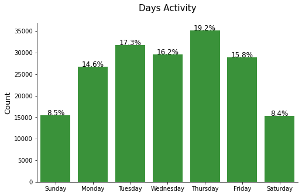

## Distribution of Trips Durations:

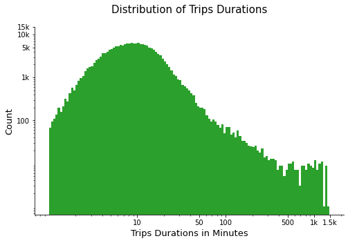

## Distribution of Customer Types:

The data is showing that the subscriber customers are making most of the trips activity with more than 89%.

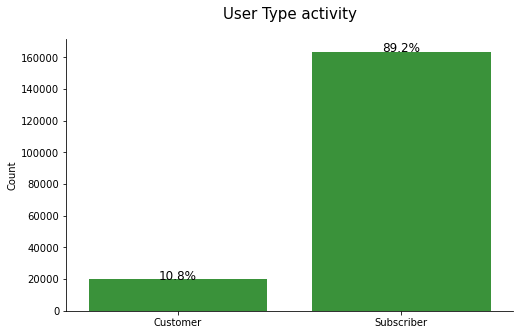

## Days Activity vs Average Trips Durations

Plotting the average durations against the days activity showing that the high duration strips were happening during the weekends. while most of 12 minutes average trips were made during the workdays.

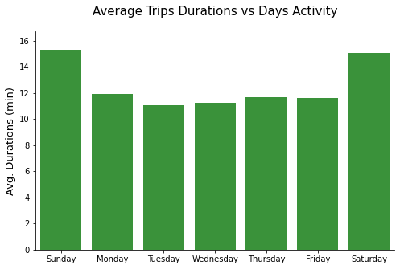

## Durations vs Customer type

Data is also showing most of the high duration trips were made by the casual costomers.

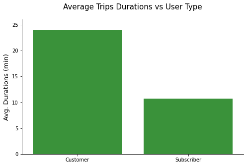

## Days Activity vs Customer type

Plotting the Days activity against the customer types to see that our subscribers were making the highest bike rents, and most of these rents were made during the workdays.

[figure not shown]

## Average Trips Durations by Days Activity and User Types

We can see from the below plot how are the casual customers are making the higher trips durations during the weekends, while the subscribers are dominating the lower duration rates.

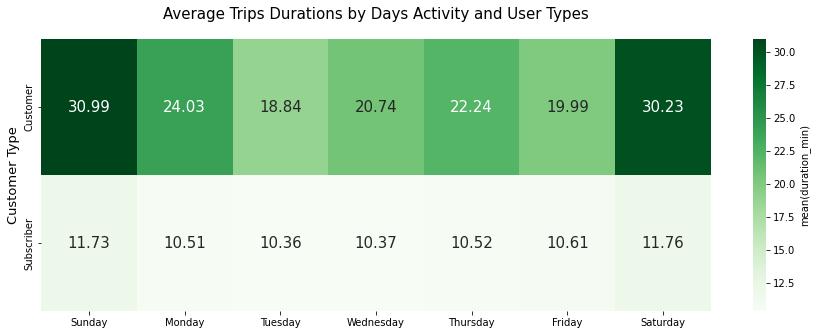